# prod_analysis

Author

Olaf König

```r
# Data manipulation
library(tidyverse)
library(readr)
library(readxl)

# Data visualization
library(ggplot2)
library(DatawRappr)
library(ggrepel)
library(knitr)

# Utility
library(here)
library(janitor)

# Custom theme for plots
theme_set(theme_minimal())

# Disable scientific notation
options(scipen = 999)
# # Re-enable scientific notation (default behavior)
# options(scipen = 0)

# Define project paths
input_raw_dir <- here("input", "raw")
input_processed_dir <- here("input", "processed")
output_dir <- here("output")
```

## 1 Import des datasets

```r
library(sf)
library(mapview)
st_layers(file.path(input_processed_dir, "historisierte-administrative_grenzen_g1_2025-01-01_2056.gpkg"))
```

```
Driver: GPKG
Available layers:
             layer_name geometry_type features fields       crs_name
1      Lacs_G1_20250101 Multi Polygon       22     11 CH1903+ / LV95
2  Communes_G1_20250101 Multi Polygon     2137     25 CH1903+ / LV95
3 Districts_G1_20250101 Multi Polygon      143     19 CH1903+ / LV95
4   Cantons_G1_20250101 Multi Polygon       26     15 CH1903+ / LV95
5   Country_G1_20250101 Multi Polygon        4     14 CH1903+ / LV95
```

```r
sf_lakes <- read_sf(
  dsn = file.path(input_processed_dir, "historisierte-administrative_grenzen_g1_2025-01-01_2056.gpkg"),
  layer = "Lacs_G1_20250101"
)

sf_canton_original <- read_sf(
  dsn = file.path(input_processed_dir, "historisierte-administrative_grenzen_g1_2025-01-01_2056.gpkg"),
  layer = "Cantons_G1_20250101"
)  |>
  select(1:2)

# Soustraction des lacs
sf_canton <- rmapshaper::ms_erase(sf_canton_original, sf_lakes)
```

```r
df_discipline <- read.csv(file.path(input_processed_dir, "students_entries_spectialities_24_25_cantons.csv")) |>
  select(-any_of(c("Unnamed: 0", "Unnamed..0", "X")))
```

## 2 1. Taux de réussite par canton (sans double comptage)

```r
min_n <- 50

# Macro-régions BFS (Grossregionen) pour une lecture régionale pertinente.
canton_macroregion <- tribble(
  ~canton, ~macroregion,
  "GE", "Région lémanique",
  "VD", "Région lémanique",
  "VS", "Région lémanique",
  "BE", "Espace Mittelland",
  "FR", "Espace Mittelland",
  "JU", "Espace Mittelland",
  "NE", "Espace Mittelland",
  "SO", "Espace Mittelland",
  "AG", "Suisse du Nord-Ouest",
  "BL", "Suisse du Nord-Ouest",
  "BS", "Suisse du Nord-Ouest",
  "ZH", "Zurich",
  "AI", "Suisse orientale",
  "AR", "Suisse orientale",
  "GL", "Suisse orientale",
  "GR", "Suisse orientale",
  "SG", "Suisse orientale",
  "SH", "Suisse orientale",
  "TG", "Suisse orientale",
  "LU", "Suisse centrale",
  "NW", "Suisse centrale",
  "OW", "Suisse centrale",
  "SZ", "Suisse centrale",
  "UR", "Suisse centrale",
  "ZG", "Suisse centrale",
  "TI", "Tessin"
)

stopifnot(setequal(
  sort(unique(df_discipline$canton[df_discipline$canton != "ZZ"])),
  sort(canton_macroregion$canton)
))

# Le dataset est en format long et contient des lignes "TOTAL".
# Pour éviter le double comptage, on définit explicitement 3 grains d'analyse.
df_canton_total_long <- df_discipline %>%
  filter(
    canton != "ZZ",
    domaine == "TOTAL",
    unite == "TOTAL",
    institution == "Total"
  )

df_canton_domaine_long <- df_discipline %>%
  filter(
    canton != "ZZ",
    domaine != "TOTAL",
    unite == "TOTAL",
    institution == "Total"
  )

df_canton_uni_long <- df_discipline %>%
  filter(
    canton != "ZZ",
    domaine == "TOTAL",
    unite != "TOTAL",
    institution != "Total"
  )

# Contrôles qualité: aucune clé ne doit être dupliquée après filtrage.
qa_uniqueness <- tibble(
  niveau = c("canton_total", "canton_x_branche", "canton_x_universite"),
  dup_keys = c(
    nrow(df_canton_total_long) - nrow(distinct(df_canton_total_long, canton, region, metric)),
    nrow(df_canton_domaine_long) - nrow(distinct(df_canton_domaine_long, canton, region, domaine, metric)),
    nrow(df_canton_uni_long) - nrow(distinct(df_canton_uni_long, canton, region, institution, metric))
  )
)

stopifnot(all(qa_uniqueness$dup_keys == 0))

df_cantonal_success_rate <- df_canton_total_long %>%
  group_by(canton, region, metric) %>%
  summarise(valeur = sum(valeur, na.rm = TRUE), .groups = "drop") %>%
  pivot_wider(names_from = metric, values_from = valeur) %>%
  left_join(canton_macroregion, by = "canton") %>%
  mutate(
    success_rate = diplomes / etudiants_automne * 100,
    success_io = diplomes / entrants_automne * 100
  )

df_cantonal_success_rate_robust <- df_cantonal_success_rate %>%
  filter(
    diplomes >= min_n,
    entrants_automne >= min_n,
    etudiants_automne >= min_n
  )

df_canton_domaine <- df_canton_domaine_long %>%
  group_by(canton, region, domaine, metric) %>%
  summarise(valeur = sum(valeur, na.rm = TRUE), .groups = "drop") %>%
  pivot_wider(names_from = metric, values_from = valeur) %>%
  left_join(canton_macroregion, by = "canton") %>%
  mutate(
    success_rate = diplomes / etudiants_automne * 100,
    success_io = diplomes / entrants_automne * 100
  )

df_canton_domaine_robust <- df_canton_domaine %>%
  filter(
    diplomes >= min_n,
    entrants_automne >= min_n,
    etudiants_automne >= min_n
  )

df_canton_uni <- df_canton_uni_long %>%
  group_by(canton, region, institution, metric) %>%
  summarise(valeur = sum(valeur, na.rm = TRUE), .groups = "drop") %>%
  pivot_wider(names_from = metric, values_from = valeur) %>%
  left_join(canton_macroregion, by = "canton") %>%
  mutate(
    success_rate = diplomes / etudiants_automne * 100,
    success_io = diplomes / entrants_automne * 100
  )

df_canton_uni_robust <- df_canton_uni %>%
  filter(
    diplomes >= min_n,
    entrants_automne >= min_n,
    etudiants_automne >= min_n
  )

# Comparaison avec une approche naïve (somme sur toutes les lignes, donc double comptage).
df_naive_canton <- df_discipline %>%
  filter(canton != "ZZ") %>%
  group_by(canton, region, metric) %>%
  summarise(valeur = sum(valeur, na.rm = TRUE), .groups = "drop") %>%
  pivot_wider(names_from = metric, values_from = valeur) %>%
  left_join(canton_macroregion, by = "canton")

qa_double_count <- df_cantonal_success_rate %>%
  select(canton, region, macroregion, diplomes, etudiants_automne, entrants_automne) %>%
  rename_with(~paste0("robust_", .x), c(diplomes, etudiants_automne, entrants_automne)) %>%
  left_join(
    df_naive_canton %>%
      rename_with(~paste0("naive_", .x), c(diplomes, etudiants_automne, entrants_automne)),
    by = c("canton", "region", "macroregion")
  ) %>%
  mutate(
    inflation_diplomes = naive_diplomes / robust_diplomes,
    inflation_etudiants = naive_etudiants_automne / robust_etudiants_automne,
    inflation_entrants = naive_entrants_automne / robust_entrants_automne
  ) %>%
  summarise(
    inflation_median_diplomes = median(inflation_diplomes, na.rm = TRUE),
    inflation_median_etudiants = median(inflation_etudiants, na.rm = TRUE),
    inflation_median_entrants = median(inflation_entrants, na.rm = TRUE)
  ) %>%
  mutate(across(everything(), round, 2))
```

### 2.1 Contrôle anti-double comptage

```r
kable(qa_uniqueness, caption = "Contrôle d'unicité des clés après filtrage des lignes TOTAL")
```

Contrôle d’unicité des clés après filtrage des lignes TOTAL

| niveau | dup_keys |
| --- | --- |
| canton_total | 0 |
| canton_x_branche | 0 |
| canton_x_universite | 0 |

```r
kable(
  qa_double_count,
  caption = "Facteur médian d'inflation si on somme naïvement toutes les lignes (double comptage)"
)
```

Facteur médian d’inflation si on somme naïvement toutes les lignes (double comptage)

| inflation_median_diplomes | inflation_median_etudiants | inflation_median_entrants |
| --- | --- | --- |
| 4 | 4 | 4 |

```r
infl <- qa_double_count[1, ]
cat(
  sprintf(
    "- En médiane, une somme naïve sur toutes les lignes multiplie les volumes par ~%.1fx (diplômés), ~%.1fx (étudiants) et ~%.1fx (entrants).\n",
    infl$inflation_median_diplomes,
    infl$inflation_median_etudiants,
    infl$inflation_median_entrants
  )
)
```

- En médiane, une somme naïve sur toutes les lignes multiplie les volumes par ~4.0x (diplômés), ~4.0x (étudiants) et ~4.0x (entrants).

### 2.2 Tableau cantonal: volumes et ratios

```r
df_canton_success_table <- df_cantonal_success_rate_robust %>%
  transmute(
    canton,
    region,
    macroregion,
    etudiants_automne,
    entrants_automne,
    diplomes,
    `diplomes_etudiants_pct` = round(success_rate, 2),
    `diplomes_entrants_pct` = round(success_io, 2)
  ) %>%
  arrange(desc(diplomes_etudiants_pct))

kable(
  df_canton_success_table,
  caption = paste0("Taux de réussite par canton (cellules conservées: seuil >= ", min_n, ")")
)
```

Taux de réussite par canton (cellules conservées: seuil >= 50)

| canton | region | macroregion | etudiants_automne | entrants_automne | diplomes | diplomes_etudiants_pct | diplomes_entrants_pct |
| --- | --- | --- | --- | --- | --- | --- | --- |
| JU | Jura | Espace Mittelland | 920 | 141 | 245 | 26.63 | 173.76 |
| VS | Valais–Wallis | Région lémanique | 4503 | 745 | 1187 | 26.36 | 159.33 |
| NW | Nidwalden | Suisse centrale | 476 | 69 | 125 | 26.26 | 181.16 |
| TI | Ticino | Tessin | 5942 | 955 | 1554 | 26.15 | 162.72 |
| OW | Obwalden | Suisse centrale | 402 | 55 | 103 | 25.62 | 187.27 |
| GR | Graubünden–Grigioni–Grischun | Suisse orientale | 2113 | 300 | 538 | 25.46 | 179.33 |
| GE | Genève | Région lémanique | 10627 | 1809 | 2677 | 25.19 | 147.98 |
| FR | Fribourg–Freiburg | Espace Mittelland | 5027 | 788 | 1247 | 24.81 | 158.25 |
| VD | Vaud | Région lémanique | 15595 | 2763 | 3850 | 24.69 | 139.34 |
| BE | Bern–Berne | Espace Mittelland | 11806 | 1729 | 2839 | 24.05 | 164.20 |
| AR | AppenzellA.Rh. | Suisse orientale | 534 | 61 | 128 | 23.97 | 209.84 |
| LU | Luzern | Suisse centrale | 4772 | 714 | 1138 | 23.85 | 159.38 |
| ZG | Zug | Suisse centrale | 2068 | 309 | 484 | 23.40 | 156.63 |
| AG | Aargau | Suisse du Nord-Ouest | 7707 | 1199 | 1798 | 23.33 | 149.96 |
| SZ | Schwyz | Suisse centrale | 1702 | 246 | 389 | 22.86 | 158.13 |
| SO | Solothurn | Espace Mittelland | 3032 | 456 | 690 | 22.76 | 151.32 |
| SG | St.Gallen | Suisse orientale | 5269 | 736 | 1193 | 22.64 | 162.09 |
| BL | Basel-Landschaft | Suisse du Nord-Ouest | 4306 | 608 | 969 | 22.50 | 159.38 |
| NE | Neuchâtel | Espace Mittelland | 3152 | 519 | 705 | 22.37 | 135.84 |
| BS | Basel-Stadt | Suisse du Nord-Ouest | 3014 | 452 | 672 | 22.30 | 148.67 |
| TG | Thurgau | Suisse orientale | 2428 | 362 | 541 | 22.28 | 149.45 |
| SH | Schaffhausen | Suisse orientale | 763 | 111 | 161 | 21.10 | 145.05 |
| ZH | Zürich | Zurich | 20515 | 3062 | 4316 | 21.04 | 140.95 |

### 2.3 Graphiques des deux ratios

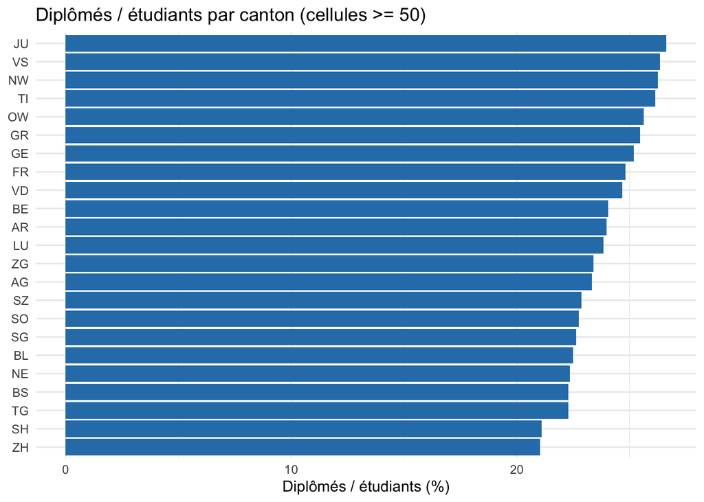

```r
ggplot(
  df_cantonal_success_rate_robust,
  aes(x = fct_reorder(canton, success_rate), y = success_rate)
) +
  geom_col(fill = "#2C7FB8") +
  coord_flip() +
  labs(
    title = paste0("Diplômés / étudiants par canton (cellules >= ", min_n, ")"),
    x = NULL,
    y = "Diplômés / étudiants (%)"
  ) +
  theme_minimal()
```

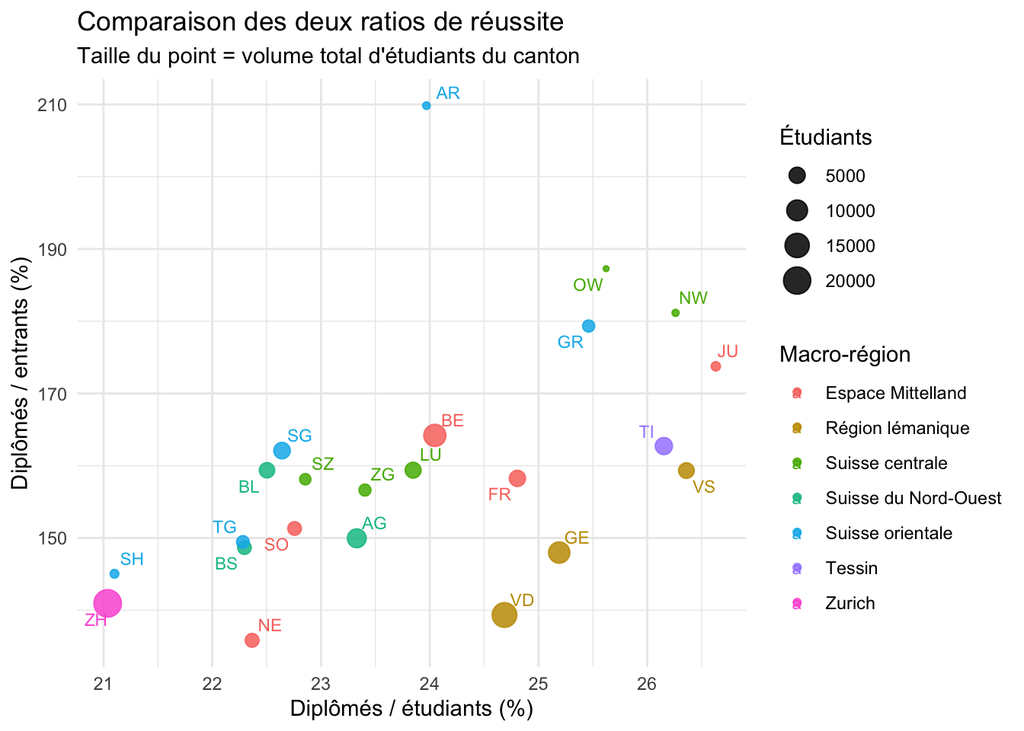

```r
ggplot(
  df_cantonal_success_rate_robust,
  aes(x = success_rate, y = success_io, label = canton, size = etudiants_automne, color = macroregion)
) +
  geom_point(alpha = 0.85) +
  ggrepel::geom_text_repel(size = 3, max.overlaps = 25) +
  labs(
    title = "Comparaison des deux ratios de réussite",
    subtitle = "Taille du point = volume total d'étudiants du canton",
    x = "Diplômés / étudiants (%)",
    y = "Diplômés / entrants (%)",
    size = "Étudiants",
    color = "Macro-région"
  ) +
  theme_minimal()
```

## 3 2. Différences régionales entre cantons

Macro-régions utilisées: classification BFS (Grossregionen).

**Interprétation des indicateurs** - `diplomes / etudiants_automne`: proxy d’un taux de réussite annuel. - `diplomes / entrants_automne`: rapport stock/flux; peut dépasser 100% car diplômés et entrants ne sont pas la même cohorte.

```r
df_macroregion_summary <- df_cantonal_success_rate_robust %>%
  group_by(macroregion) %>%
  summarise(
    cantons = n(),
    etudiants_automne = sum(etudiants_automne, na.rm = TRUE),
    entrants_automne = sum(entrants_automne, na.rm = TRUE),
    diplomes = sum(diplomes, na.rm = TRUE),
    success_rate_pondere = diplomes / etudiants_automne * 100,
    success_io_pondere = diplomes / entrants_automne * 100,
    median_success_rate = median(success_rate, na.rm = TRUE),
    iqr_success_rate = IQR(success_rate, na.rm = TRUE),
    sd_success_rate = if_else(n() > 1, sd(success_rate, na.rm = TRUE), 0),
    .groups = "drop"
  ) %>%
  arrange(desc(success_rate_pondere))

df_canton_vs_region <- df_cantonal_success_rate_robust %>%
  left_join(
    df_macroregion_summary %>%
      select(macroregion, success_rate_pondere, success_io_pondere),
    by = "macroregion"
  ) %>%
  mutate(
    gap_rate_region_pp = success_rate - success_rate_pondere,
    gap_io_region_pp = success_io - success_io_pondere
  )

df_extremes_region_gap <- bind_rows(
  df_canton_vs_region %>% arrange(desc(gap_rate_region_pp)) %>% slice_head(n = 6),
  df_canton_vs_region %>% arrange(gap_rate_region_pp) %>% slice_head(n = 6)
) %>%
  select(canton, region, macroregion, etudiants_automne, success_rate, success_rate_pondere, gap_rate_region_pp, success_io, gap_io_region_pp) %>%
  mutate(
    across(c(success_rate, success_rate_pondere, gap_rate_region_pp, success_io, gap_io_region_pp), round, 2)
  )
```

### 3.1 Lecture régionale: niveaux et dispersion

```r
kable(
  df_macroregion_summary %>%
    mutate(across(c(success_rate_pondere, success_io_pondere, median_success_rate, iqr_success_rate, sd_success_rate), round, 2)),
  caption = "Synthèse par macro-région BFS (pondérée par volume étudiant)"
)
```

Synthèse par macro-région BFS (pondérée par volume étudiant)

| macroregion | cantons | etudiants_automne | entrants_automne | diplomes | success_rate_pondere | success_io_pondere | median_success_rate | iqr_success_rate | sd_success_rate |
| --- | --- | --- | --- | --- | --- | --- | --- | --- | --- |
| Tessin | 1 | 5942 | 955 | 1554 | 26.15 | 162.72 | 26.15 | 0.00 | 0.00 |
| Région lémanique | 3 | 30725 | 5317 | 7714 | 25.11 | 145.08 | 25.19 | 0.84 | 0.86 |
| Espace Mittelland | 5 | 23937 | 3633 | 5726 | 23.92 | 157.61 | 24.05 | 2.05 | 1.71 |
| Suisse centrale | 5 | 9420 | 1393 | 2239 | 23.77 | 160.73 | 23.85 | 2.22 | 1.47 |
| Suisse orientale | 5 | 11107 | 1570 | 2561 | 23.06 | 163.12 | 22.64 | 1.69 | 1.67 |
| Suisse du Nord-Ouest | 3 | 15027 | 2259 | 3439 | 22.89 | 152.24 | 22.50 | 0.52 | 0.55 |
| Zurich | 1 | 20515 | 3062 | 4316 | 21.04 | 140.95 | 21.04 | 0.00 | 0.00 |

### 3.2 Cantons au-dessus / en-dessous de leur moyenne régionale

```r
kable(
  df_extremes_region_gap,
  caption = "Top 6 / Bottom 6 des écarts cantonaux à la moyenne de leur région (points de %)"
)
```

Top 6 / Bottom 6 des écarts cantonaux à la moyenne de leur région (points de %)

| canton | region | macroregion | etudiants_automne | success_rate | success_rate_pondere | gap_rate_region_pp | success_io | gap_io_region_pp |
| --- | --- | --- | --- | --- | --- | --- | --- | --- |
| JU | Jura | Espace Mittelland | 920 | 26.63 | 23.92 | 2.71 | 173.76 | 16.15 |
| NW | Nidwalden | Suisse centrale | 476 | 26.26 | 23.77 | 2.49 | 181.16 | 20.43 |
| GR | Graubünden–Grigioni–Grischun | Suisse orientale | 2113 | 25.46 | 23.06 | 2.40 | 179.33 | 16.21 |
| OW | Obwalden | Suisse centrale | 402 | 25.62 | 23.77 | 1.85 | 187.27 | 26.54 |
| VS | Valais–Wallis | Région lémanique | 4503 | 26.36 | 25.11 | 1.25 | 159.33 | 14.25 |
| AR | AppenzellA.Rh. | Suisse orientale | 534 | 23.97 | 23.06 | 0.91 | 209.84 | 46.72 |
| SH | Schaffhausen | Suisse orientale | 763 | 21.10 | 23.06 | -1.96 | 145.05 | -18.08 |
| NE | Neuchâtel | Espace Mittelland | 3152 | 22.37 | 23.92 | -1.55 | 135.84 | -21.77 |
| SO | Solothurn | Espace Mittelland | 3032 | 22.76 | 23.92 | -1.16 | 151.32 | -6.30 |
| SZ | Schwyz | Suisse centrale | 1702 | 22.86 | 23.77 | -0.91 | 158.13 | -2.60 |
| TG | Thurgau | Suisse orientale | 2428 | 22.28 | 23.06 | -0.78 | 149.45 | -13.67 |
| BS | Basel-Stadt | Suisse du Nord-Ouest | 3014 | 22.30 | 22.89 | -0.59 | 148.67 | -3.56 |

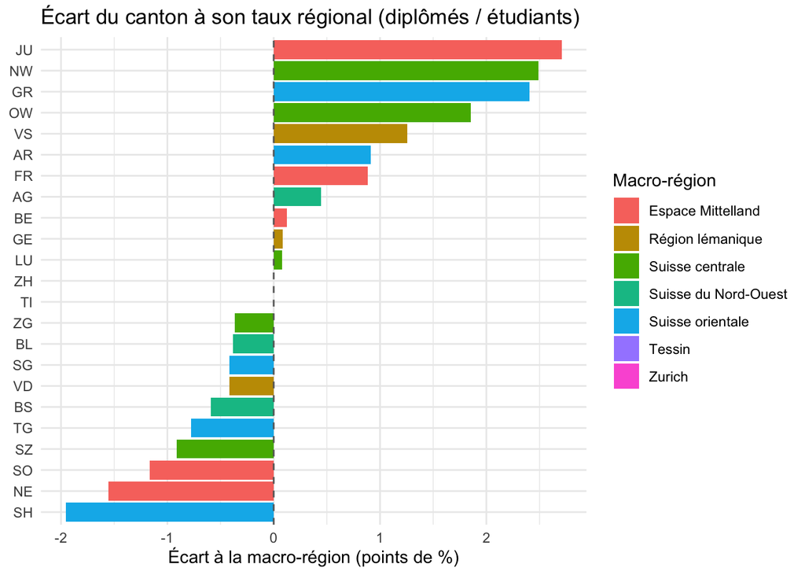

```r
ggplot(
  df_canton_vs_region,
  aes(x = fct_reorder(canton, gap_rate_region_pp), y = gap_rate_region_pp, fill = macroregion)
) +
  geom_col() +
  geom_hline(yintercept = 0, linetype = 2, color = "grey40") +
  coord_flip() +
  labs(
    title = "Écart du canton à son taux régional (diplômés / étudiants)",
    x = NULL,
    y = "Écart à la macro-région (points de %)",
    fill = "Macro-région"
  ) +
  theme_minimal()
```

### 3.3 Points saillants

```r
top_macro <- df_macroregion_summary %>% slice_max(success_rate_pondere, n = 1)
bottom_macro <- df_macroregion_summary %>% slice_min(success_rate_pondere, n = 1)
widest_disp <- df_macroregion_summary %>% slice_max(iqr_success_rate, n = 1)
top_canton_gap <- df_canton_vs_region %>% slice_max(gap_rate_region_pp, n = 1)
bottom_canton_gap <- df_canton_vs_region %>% slice_min(gap_rate_region_pp, n = 1)

cat(sprintf("- Macro-région la plus élevée (diplômés/étudiants): **%s** (%.2f%%).\n", top_macro$macroregion, top_macro$success_rate_pondere))
```

- Macro-région la plus élevée (diplômés/étudiants): **Tessin** (26.15%).

```r
cat(sprintf("- Macro-région la plus basse: **%s** (%.2f%%).\n", bottom_macro$macroregion, bottom_macro$success_rate_pondere))
```

- Macro-région la plus basse: **Zurich** (21.04%).

```r
cat(sprintf("- Dispersion intra-macro-région la plus forte (IQR): **%s** (%.2f points).\n", widest_disp$macroregion, widest_disp$iqr_success_rate))
```

- Dispersion intra-macro-région la plus forte (IQR): **Suisse centrale** (2.22 points).

```r
cat(sprintf("- Plus forte surperformance cantonale vs sa macro-région: **%s** (%+.2f points).\n", top_canton_gap$canton, top_canton_gap$gap_rate_region_pp))
```

- Plus forte surperformance cantonale vs sa macro-région: **JU** (+2.71 points).

```r
cat(sprintf("- Plus forte sous-performance cantonale vs sa macro-région: **%s** (%+.2f points).\n", bottom_canton_gap$canton, bottom_canton_gap$gap_rate_region_pp))
```

- Plus forte sous-performance cantonale vs sa macro-région: **SH** (-1.96 points).

### 3.4 Vérification de couverture

```r
coverage_tbl <- tibble(
  niveau = c("cantons", "canton x branche", "canton x université"),
  cellules = c(
    nrow(df_cantonal_success_rate_robust),
    nrow(df_canton_domaine_robust),
    nrow(df_canton_uni_robust)
  )
)

kable(coverage_tbl, caption = paste0("Nombre de cellules conservées avec seuil >= ", min_n))
```

Nombre de cellules conservées avec seuil >= 50

| niveau | cellules |
| --- | --- |
| cantons | 23 |
| canton x branche | 96 |
| canton x université | 72 |

## 4 3. Décomposition par branche (mix vs performance)

```r
branch_benchmark <- df_canton_domaine_robust %>%
  group_by(domaine) %>%
  summarise(
    branch_rate = sum(diplomes, na.rm = TRUE) / sum(etudiants_automne, na.rm = TRUE) * 100,
    .groups = "drop"
  )

national_rate_branch <- df_canton_domaine_robust %>%
  summarise(rate = sum(diplomes, na.rm = TRUE) / sum(etudiants_automne, na.rm = TRUE) * 100) %>%
  pull(rate)

df_canton_branch_decomp <- df_canton_domaine_robust %>%
  left_join(branch_benchmark, by = "domaine") %>%
  group_by(canton, region) %>%
  summarise(
    actual_rate = sum(diplomes, na.rm = TRUE) / sum(etudiants_automne, na.rm = TRUE) * 100,
    expected_mix_rate = sum((etudiants_automne / sum(etudiants_automne, na.rm = TRUE)) * branch_rate, na.rm = TRUE),
    .groups = "drop"
  ) %>%
  mutate(
    total_gap_pp = actual_rate - national_rate_branch,
    mix_effect_pp = expected_mix_rate - national_rate_branch,
    within_effect_pp = actual_rate - expected_mix_rate
  ) %>%
  arrange(desc(total_gap_pp))
```

### 4.1 Quels cantons sur/sous-performent à mix de branches comparable

```r
decomp_top_bottom <- bind_rows(
  df_canton_branch_decomp %>% arrange(desc(within_effect_pp)) %>% slice_head(n = 5),
  df_canton_branch_decomp %>% arrange(within_effect_pp) %>% slice_head(n = 5)
) %>%
  mutate(across(c(actual_rate, expected_mix_rate, total_gap_pp, mix_effect_pp, within_effect_pp), round, 2))

kable(
  decomp_top_bottom %>% select(canton, region, actual_rate, expected_mix_rate, mix_effect_pp, within_effect_pp),
  caption = "Top/Bottom 5 de l'effet performance interne (points de %)"
)
```

Top/Bottom 5 de l’effet performance interne (points de %)

| canton | region | actual_rate | expected_mix_rate | mix_effect_pp | within_effect_pp |
| --- | --- | --- | --- | --- | --- |
| TI | Ticino | 26.23 | 23.34 | -0.17 | 2.88 |
| VS | Valais–Wallis | 25.90 | 23.30 | -0.21 | 2.60 |
| GR | Graubünden–Grigioni–Grischun | 24.80 | 22.33 | -1.18 | 2.47 |
| GE | Genève | 25.07 | 23.35 | -0.16 | 1.72 |
| FR | Fribourg–Freiburg | 24.92 | 23.24 | -0.27 | 1.68 |
| ZH | Zürich | 21.04 | 23.75 | 0.23 | -2.71 |
| TG | Thurgau | 20.54 | 23.01 | -0.50 | -2.48 |
| BS | Basel-Stadt | 21.09 | 22.96 | -0.55 | -1.88 |
| SZ | Schwyz | 22.30 | 23.60 | 0.08 | -1.29 |
| NE | Neuchâtel | 21.97 | 23.24 | -0.28 | -1.27 |

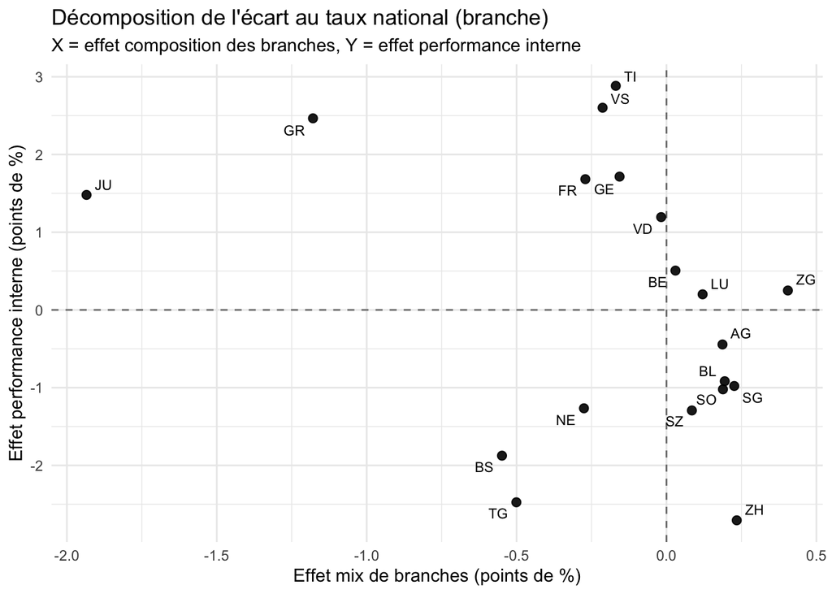

```r
ggplot(
  df_canton_branch_decomp,
  aes(x = mix_effect_pp, y = within_effect_pp, label = canton)
) +
  geom_hline(yintercept = 0, linetype = 2, color = "grey50") +
  geom_vline(xintercept = 0, linetype = 2, color = "grey50") +
  geom_point(size = 2.2, alpha = 0.9) +
  ggrepel::geom_text_repel(size = 3) +
  labs(
    title = "Décomposition de l'écart au taux national (branche)",
    subtitle = "X = effet composition des branches, Y = effet performance interne",
    x = "Effet mix de branches (points de %)",
    y = "Effet performance interne (points de %)"
  ) +
  theme_minimal()
```

### 4.2 Heatmap canton x branche (écart au benchmark de branche)

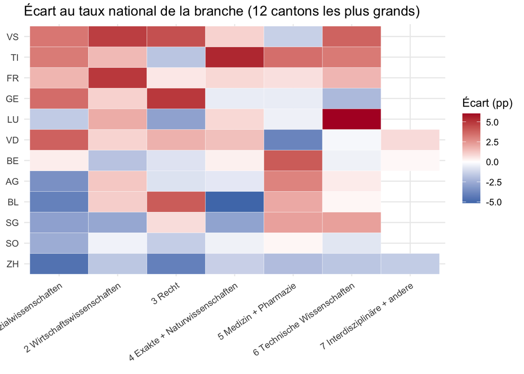

```r
top_cantons_branch <- df_canton_domaine_robust %>%
  group_by(canton) %>%
  summarise(etudiants = sum(etudiants_automne, na.rm = TRUE), .groups = "drop") %>%
  slice_max(order_by = etudiants, n = 12, with_ties = FALSE) %>%
  pull(canton)

df_branch_delta <- df_canton_domaine_robust %>%
  left_join(branch_benchmark, by = "domaine") %>%
  filter(canton %in% top_cantons_branch) %>%
  mutate(delta_pp = success_rate - branch_rate)

ggplot(
  df_branch_delta,
  aes(x = domaine, y = fct_reorder(canton, success_rate, .fun = mean), fill = delta_pp)
) +
  geom_tile(color = "white") +
  scale_fill_gradient2(low = "#2166ac", mid = "white", high = "#b2182b", midpoint = 0) +
  labs(
    title = "Écart au taux national de la branche (12 cantons les plus grands)",
    x = NULL,
    y = NULL,
    fill = "Écart (pp)"
  ) +
  theme_minimal() +
  theme(axis.text.x = element_text(angle = 35, hjust = 1))
```

## 5 4. Analyse par université

```r
uni_benchmark <- df_canton_uni_robust %>%
  group_by(institution) %>%
  summarise(
    etudiants_automne = sum(etudiants_automne, na.rm = TRUE),
    diplomes = sum(diplomes, na.rm = TRUE),
    entrants_automne = sum(entrants_automne, na.rm = TRUE),
    uni_success_rate = diplomes / etudiants_automne * 100,
    uni_success_io = diplomes / entrants_automne * 100,
    .groups = "drop"
  ) %>%
  arrange(desc(etudiants_automne))

national_rate_uni <- df_canton_uni_robust %>%
  summarise(rate = sum(diplomes, na.rm = TRUE) / sum(etudiants_automne, na.rm = TRUE) * 100) %>%
  pull(rate)
```

### 5.1 Classement des universités (pondéré par volume)

```r
uni_rank <- uni_benchmark %>%
  mutate(
    uni_success_rate = round(uni_success_rate, 2),
    uni_success_io = round(uni_success_io, 2)
  ) %>%
  select(institution, etudiants_automne, diplomes, entrants_automne, uni_success_rate, uni_success_io)

kable(uni_rank, caption = "Taux nationaux par université (cellules cantonales >= 50)")
```

Taux nationaux par université (cellules cantonales >= 50)

| institution | etudiants_automne | diplomes | entrants_automne | uni_success_rate | uni_success_io |
| --- | --- | --- | --- | --- | --- |
| Université de Zurich | 21573 | 4223 | 3098 | 19.58 | 136.31 |
| ETHZ | 13950 | 3481 | 2394 | 24.95 | 145.41 |
| Université de Lausanne | 12785 | 3194 | 2220 | 24.98 | 143.87 |
| Université de Berne | 12641 | 3167 | 1830 | 25.05 | 173.06 |
| Université de Genève | 9165 | 2475 | 1615 | 27.00 | 153.25 |
| Université de Bâle | 7682 | 1758 | 1101 | 22.88 | 159.67 |
| Université de Fribourg | 6332 | 1544 | 1022 | 24.38 | 151.08 |
| EPFL | 4977 | 1150 | 1124 | 23.11 | 102.31 |
| Université de Saint-Gall | 4630 | 1102 | 918 | 23.80 | 120.04 |
| Université de Neuchâtel | 2329 | 547 | 407 | 23.49 | 134.40 |
| Université de la Suisse italienne | 927 | 270 | 132 | 29.13 | 204.55 |
| Université de Lucerne | 890 | 182 | 148 | 20.45 | 122.97 |

### 5.2 Dépendance cantonale à quelques universités

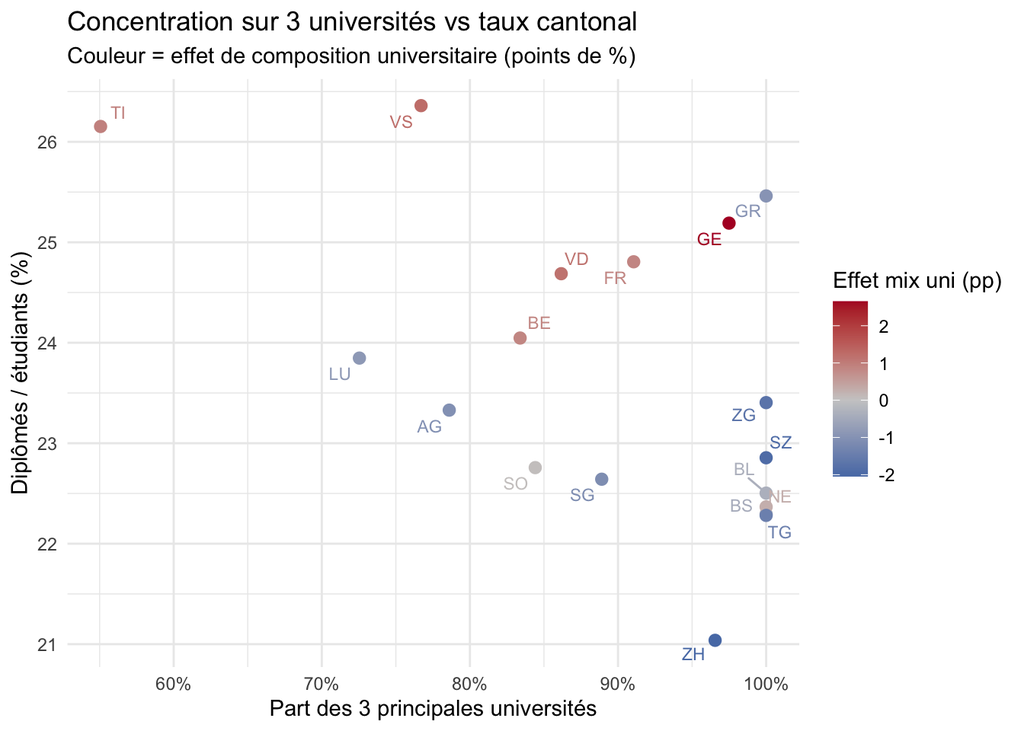

```r
df_uni_concentration <- df_canton_uni_robust %>%
  group_by(canton, region) %>%
  mutate(student_share = etudiants_automne / sum(etudiants_automne, na.rm = TRUE)) %>%
  arrange(desc(student_share), .by_group = TRUE) %>%
  mutate(rank_uni = row_number()) %>%
  summarise(
    top3_share = sum(student_share[rank_uni <= 3], na.rm = TRUE),
    n_universites = n(),
    .groups = "drop"
  )

df_uni_mix_effect <- df_canton_uni_robust %>%
  left_join(uni_benchmark %>% select(institution, uni_success_rate), by = "institution") %>%
  group_by(canton, region) %>%
  summarise(
    expected_uni_mix_rate = sum((etudiants_automne / sum(etudiants_automne, na.rm = TRUE)) * uni_success_rate, na.rm = TRUE),
    .groups = "drop"
  ) %>%
  mutate(uni_mix_effect_pp = expected_uni_mix_rate - national_rate_uni)

df_uni_reading <- df_cantonal_success_rate_robust %>%
  select(canton, region, success_rate) %>%
  inner_join(df_uni_concentration, by = c("canton", "region")) %>%
  inner_join(df_uni_mix_effect, by = c("canton", "region"))

ggplot(
  df_uni_reading,
  aes(x = top3_share, y = success_rate, label = canton, color = uni_mix_effect_pp)
) +
  geom_point(size = 2.4) +
  ggrepel::geom_text_repel(size = 3) +
  scale_color_gradient2(low = "#2166ac", mid = "grey80", high = "#b2182b", midpoint = 0) +
  scale_x_continuous(labels = scales::percent_format(accuracy = 1)) +
  labs(
    title = "Concentration sur 3 universités vs taux cantonal",
    subtitle = "Couleur = effet de composition universitaire (points de %)",
    x = "Part des 3 principales universités",
    y = "Diplômés / étudiants (%)",
    color = "Effet mix uni (pp)"
  ) +
  theme_minimal()
```

### 5.3 Questions éditoriales à creuser

- Les cantons au-dessus de la moyenne nationale le sont-ils surtout via leur **mix de branches** ou via une **surperformance interne**?
- Les cantons très concentrés sur peu d’universités ont-ils des profils de réussite plus volatils?
- Les écarts les plus forts se jouent-ils dans quelques branches (médecine, technique, etc.) ou sont-ils diffus?

## 6 DW cantonal success rate

https://app.datawrapper.de/tamedia/edit/WNduM/upload

```r
df_cantonal_success_rate_robust %>%
  dw_data_to_chart("WNduM")
```